# Do we do better when covariates are less associated?

## Introduction

Unlike previous notebooks, there isn’t anything new here. What you’ll see instead is analysis of two data sets generated with less association among the covariates than the data sets you’ve seen in earlier notebooks. The analysis will use `rstanarm`, horseshoe priors, and projection prediction variable selection.

NOTE: Data the data not scaled so that regression coefficients are *more* comparable across the two data sets. You may want to return to some of the earlier notebooks where the data were scaled and re-run the analyses to see how the results change.

```r
library(tidyverse)
library(reshape2)
library(ggplot2)
library(cowplot)
library(mvtnorm)
library(corrplot)

rm(list = ls())
```

```r
## intetcept
##
beta0 <- 1.0
## regression coefficients
##
beta <- c(1.0, -1.0, 1.0, 0.0, 0.0, 0.0, 0.0, 0.0, 0.0)
## pattern of correlation matrix, all non-zero entries are set to saem
## correlation, covariance matrix caldulated from individual variances and a
## single association parameter governing the non-zero correlation coefficients
##
## Note: Not just any pattern will work here. The correlation matrix and
## covariance matrix generated from this pattern must be positive definite.
## If you change this pattern, you may get an error when you try to generate
## data with a non-zero association parameter.
##
Rho <- matrix(nrow = 9, ncol = , byrow = TRUE,
              data = c(1,0,1,0,1,0,1,0,1,
                       0,1,0,1,0,1,0,1,0,
                       1,0,1,0,1,0,1,0,1,
                       0,1,0,1,0,1,0,1,0,
                       1,0,1,0,1,0,1,0,1,
                       0,1,0,1,0,1,0,1,0,
                       1,0,1,0,1,0,1,0,1,
                       0,1,0,1,0,1,0,1,0,
                       1,0,1,0,1,0,1,0,1
                       ))
## vector of standard deviations for covariates
##
sigma <- rep(1, 9)

## construct a covariance matrix from the pattern, standard deviations, and
## one parameter in [-1,1] that governs the magnitude of non-zero correlation
## coefficients
##
## Rho - the pattern of associations
## sigma - the vector of standard deviations
## rho - the association parameter
##
construct_Sigma <- function(Rho, sigma, rho) {
  ## get the correlation matris
  ##
  Rho <- Rho*rho
  for (i in 1:ncol(Rho)) {
    Rho[i,i] <- 1.0
  }
  ## notice the use of matrix multiplication
  ##
  Sigma <- diag(sigma) %*% Rho %*% diag(sigma)
  return(Sigma)
}

## set the random number seed manually so that every run of the code will
## produce the same numbers
##
set.seed(1234)

n_samp <- 100
cov_str <- rmvnorm(n_samp,
                   mean = rep(0, nrow(Rho)),
                   sigma = construct_Sigma(Rho, sigma, 0.8))

resid <- rep(2.0, n_samp)

y_str <- rnorm(nrow(cov_str), mean = beta0 + cov_str %*% beta, sd = resid)
dat_1 <- data.frame(y_str, cov_str, rep("Strong", length(y_str)))

cov_str <- rmvnorm(n_samp,
                   mean = rep(0, nrow(Rho)),
                   sigma = construct_Sigma(Rho, sigma, 0.8))
y_str <- rnorm(nrow(cov_str), mean = beta0 + cov_str %*% beta, sd = resid)
dat_2 <- data.frame(y_str, cov_str, rep("Strong", length(y_str)))

column_names <- c("y", paste("x", seq(1, length(beta)), sep = ""), "Scenario")
colnames(dat_1) <- column_names
colnames(dat_2) <- column_names
```

### Correlation plots with `rho = 0.8`

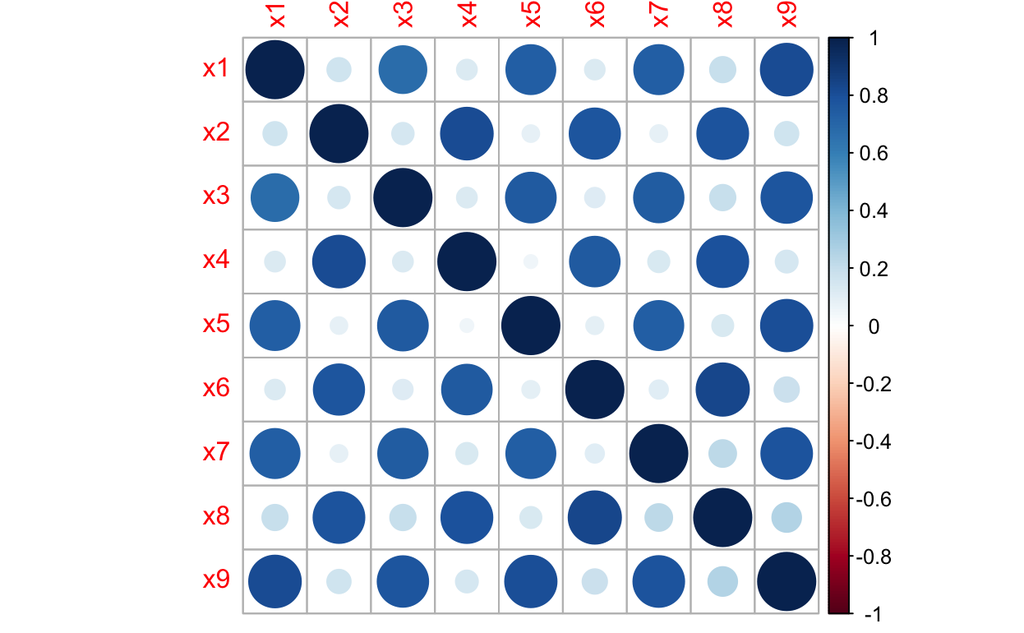

```r
corrplot(cor(dat_1[, -c(1,11)]))
```

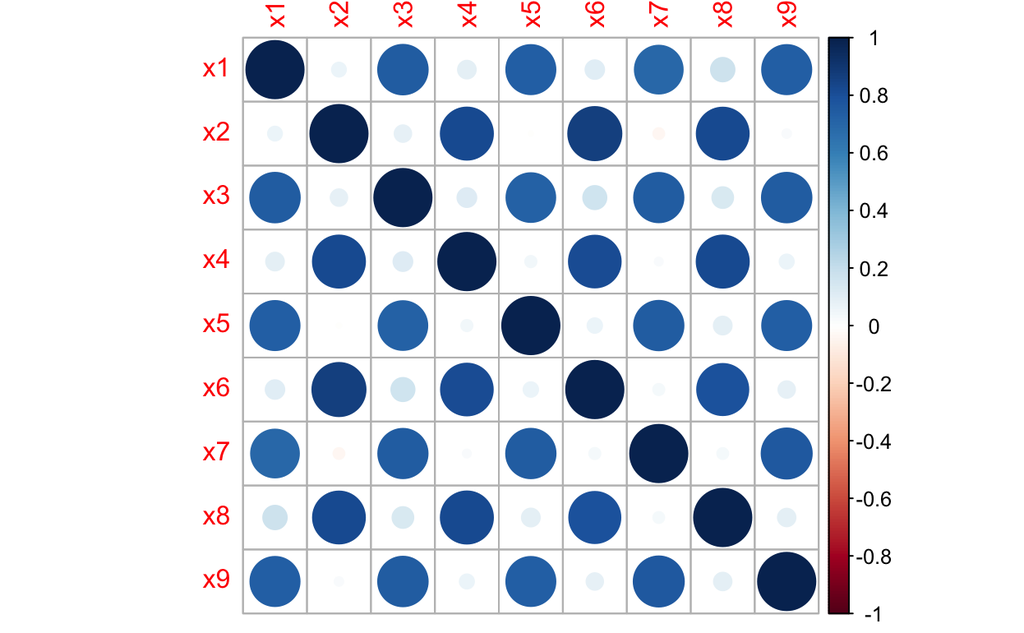

```r
corrplot(cor(dat_2[, -c(1,11)]))
```

```r
corr_08_1 <- max(abs(cor(dat_1[, -c(1,11)]) - diag(1, 9)))
corr_08_2 <- max(abs(cor(dat_2[, -c(1,11)]) - diag(1, 9)))
```

### Correlation plots with `rho = 0.2`

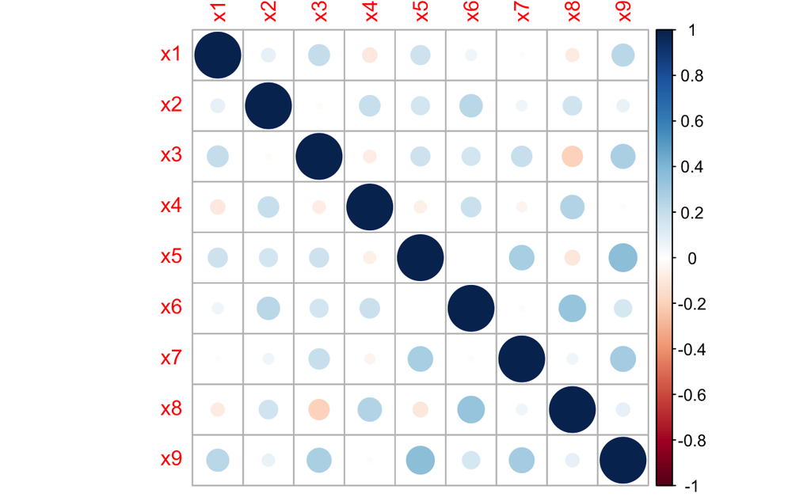

```r
n_samp <- 100
cov_str <- rmvnorm(n_samp,
                   mean = rep(0, nrow(Rho)),
                   sigma = construct_Sigma(Rho, sigma, 0.2))

resid <- rep(2.0, n_samp)

y_str <- rnorm(nrow(cov_str), mean = beta0 + cov_str %*% beta, sd = resid)
dat_1 <- data.frame(y_str, cov_str, rep("Strong", length(y_str)))

cov_str <- rmvnorm(n_samp,
                   mean = rep(0, nrow(Rho)),
                   sigma = construct_Sigma(Rho, sigma, 0.2))
y_str <- rnorm(nrow(cov_str), mean = beta0 + cov_str %*% beta, sd = resid)
dat_2 <- data.frame(y_str, cov_str, rep("Strong", length(y_str)))

column_names <- c("y", paste("x", seq(1, length(beta)), sep = ""), "Scenario")
colnames(dat_1) <- column_names
colnames(dat_2) <- column_names

corrplot(cor(dat_1[, -c(1,11)]))
```

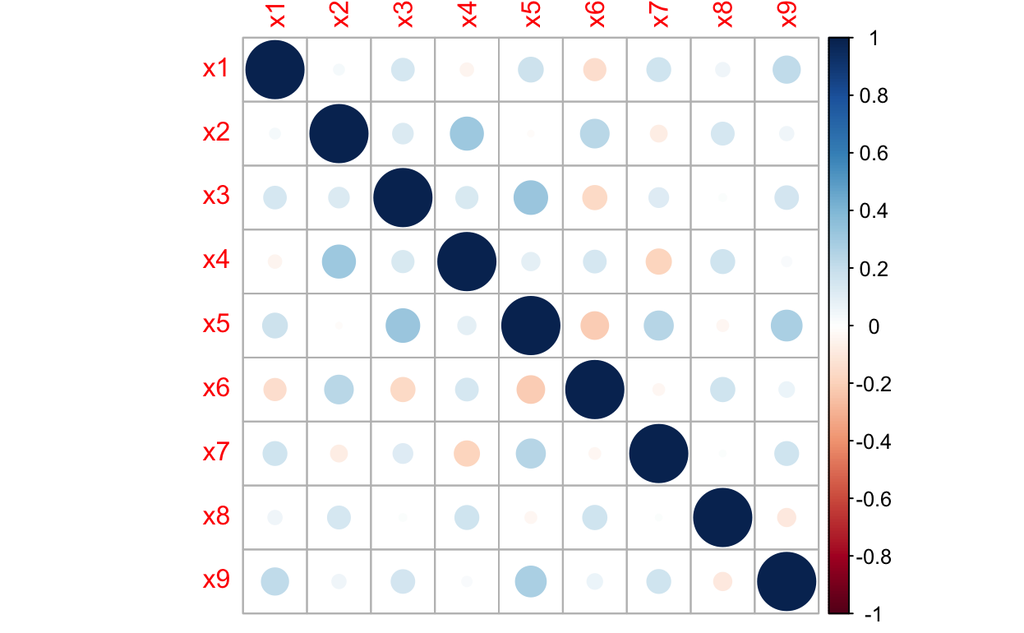

```r
corrplot(cor(dat_2[, -c(1,11)]))
```

```r
corr_02_1 <- max(abs(cor(dat_1[, -c(1,11)]) - diag(1, 9)))
corr_02_2 <- max(abs(cor(dat_2[, -c(1,11)]) - diag(1, 9)))
```

The correlation plots make it clear that the magnitude of associations among covariates is much greater with `rho = 0.8` than it is with `rho = 0.2`, but let’s look at the numerical results.

The maximum correlation in data set 1 (rho = 0.8): 0.834

The maximum correlation in data set 2 (rho = 0.8): 0.861

The maximum correlation in data set 1 (rho = 0.2): 0.365

The maximum correlation in data set 2 (rho = 0.2): 0.328

In everything that follows, we’ll be working with the data sets generated when `rho = 0.2`.

## Horseshoe priors

We’ll be working with the data set generated with relatively weak associations among covariates for the rest of this exercise, and we’ll start with horsehoe priors.[^1]

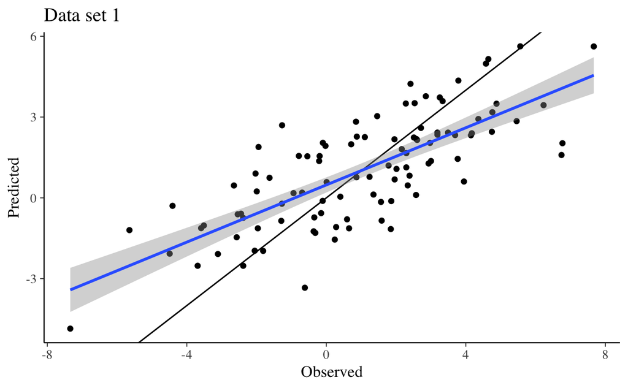

```r
library(rstanarm)

options(mc.cores = parallel::detectCores())

set.seed(1234)

## n is the number of observations
## D is the number of covariates
## p0 is the expected number of important covariates
##
n <- nrow(dat_1)
D <- ncol(dat_1[,2:10])
p0 <- 3
tau0 <- p0/(D - p0) * 1/sqrt(n)
prior_coeff <- hs(global_scale = tau0, slab_scale = 1)

fit_1 <- stan_glm(y ~ x1 + x2 + x3 + x4 + x5 + x6 + x7 + x8 + x9,
                  data = dat_1,
                  prior = prior_coeff,
                  refresh = 0,
                  adapt_delta = 0.999)
## Note: I use the same prior scale here because both data sets have the same number of observations
## and the same expected number of important covariates
##
fit_2 <- stan_glm(y ~ x1 + x2 + x3 + x4 + x5 + x6 + x7 + x8 + x9,
                  data = dat_2,
                  prior = prior_coeff,
                  refresh = 0,
                  adapt_delta = 0.999)

predict_1 <- posterior_predict(fit_1)
predict_2 <- posterior_predict(fit_2)

for.plot <- data.frame(Observed = dat_1$y, Predicted = apply(predict_1, 2, mean))
p <- ggplot(for.plot, aes(x = Observed, y = Predicted)) +
  geom_point() +
  geom_abline(slope = 1, intercept = 0) +
  geom_smooth(method = "lm") +
  ggtitle("Data set 1")
print(p)
```

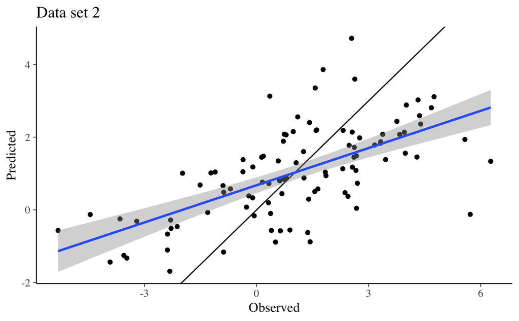

```r
for.plot <- data.frame(Observed = dat_2$y, Predicted = apply(predict_2, 2, mean))
p <- ggplot(for.plot, aes(x = Observed, y = Predicted)) +
  geom_point() +
  geom_abline(slope = 1, intercept = 0) +
  geom_smooth(method = "lm") +
  ggtitle("Data set 2")
print(p)
```

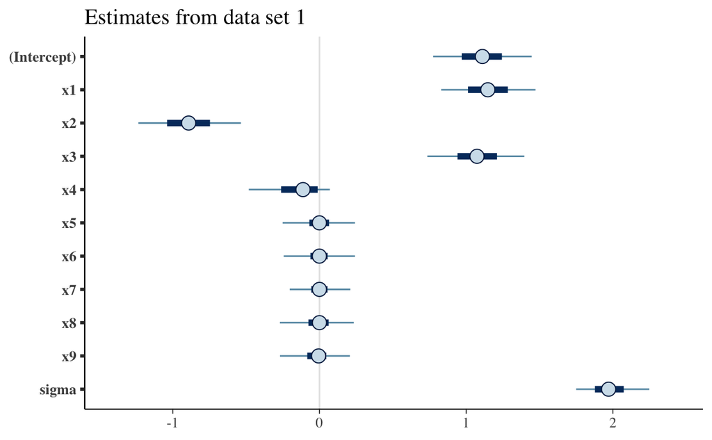

```r
p <- plot(fit_1) + ggtitle("Estimates from data set 1")
print(p)
```

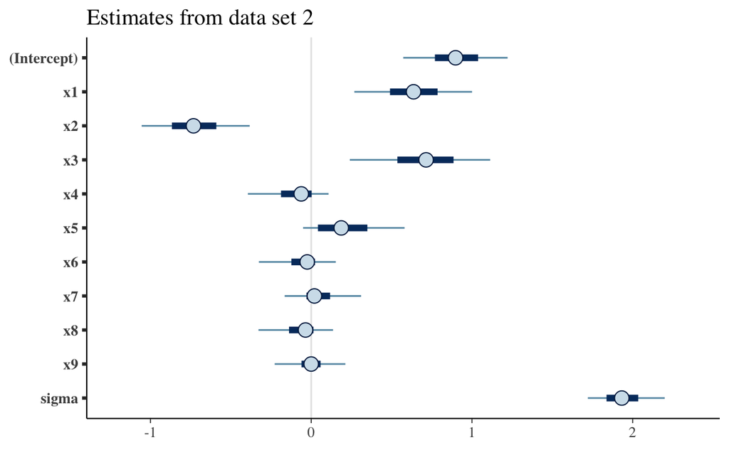

```r
p <- plot(fit_2) + ggtitle("Estimates from data set 2")
print(p)
```

```r
summary(fit_1, digits = 3)
```

```
Model Info:

 function:     stan_glm
 family:       gaussian [identity]
 formula:      y ~ x1 + x2 + x3 + x4 + x5 + x6 + x7 + x8 + x9
 algorithm:    sampling
 priors:       see help('prior_summary')
 sample:       4000 (posterior sample size)
 observations: 100
 predictors:   10

Estimates:
                mean     sd       2.5%     25%      50%      75%      97.5%
(Intercept)      1.108    0.206    0.709    0.970    1.111    1.244    1.514
x1               1.149    0.198    0.762    1.013    1.148    1.284    1.535
x2              -0.892    0.217   -1.309   -1.039   -0.892   -0.746   -0.470
x3               1.073    0.202    0.662    0.941    1.074    1.210    1.459
x4              -0.150    0.177   -0.550   -0.261   -0.112   -0.012    0.120
x5              -0.003    0.147   -0.327   -0.069   -0.001    0.065    0.307
x6              -0.001    0.138   -0.307   -0.061   -0.001    0.056    0.315
x7               0.000    0.120   -0.264   -0.056    0.000    0.055    0.262
x8              -0.008    0.147   -0.339   -0.075    0.000    0.063    0.306
x9              -0.018    0.141   -0.327   -0.083   -0.006    0.047    0.278
sigma            1.981    0.152    1.711    1.878    1.971    2.074    2.316
mean_PPD         1.014    0.281    0.444    0.829    1.011    1.199    1.563
log-posterior -270.264    4.657 -280.473 -273.091 -269.894 -267.013 -262.167

Diagnostics:
              mcse  Rhat  n_eff
(Intercept)   0.003 1.001 3728
x1            0.003 1.000 4292
x2            0.003 1.001 4166
x3            0.003 1.000 4498
x4            0.003 1.000 2570
x5            0.002 1.000 4963
x6            0.002 1.000 4470
x7            0.002 1.001 4923
x8            0.002 0.999 4766
x9            0.002 0.999 4788
sigma         0.002 0.999 4160
mean_PPD      0.005 1.002 3799
log-posterior 0.139 1.002 1127

For each parameter, mcse is Monte Carlo standard error, n_eff is a crude measure of effective sample size, and Rhat is the potential scale reduction factor on split chains (at convergence Rhat=1).
```

```r
summary(fit_2, digits = 3)
```

```
Model Info:

 function:     stan_glm
 family:       gaussian [identity]
 formula:      y ~ x1 + x2 + x3 + x4 + x5 + x6 + x7 + x8 + x9
 algorithm:    sampling
 priors:       see help('prior_summary')
 sample:       4000 (posterior sample size)
 observations: 100
 predictors:   10

Estimates:
                mean     sd       2.5%     25%      50%      75%      97.5%
(Intercept)      0.902    0.197    0.508    0.770    0.898    1.038    1.284
x1               0.637    0.221    0.185    0.490    0.637    0.786    1.066
x2              -0.726    0.205   -1.108   -0.867   -0.733   -0.590   -0.312
x3               0.705    0.263    0.133    0.536    0.715    0.886    1.184
x4              -0.097    0.157   -0.461   -0.188   -0.062    0.002    0.166
x5               0.211    0.206   -0.097    0.042    0.187    0.349    0.659
x6              -0.054    0.144   -0.389   -0.123   -0.025    0.023    0.205
x7               0.045    0.143   -0.229   -0.030    0.020    0.117    0.378
x8              -0.065    0.141   -0.391   -0.138   -0.036    0.014    0.191
x9              -0.002    0.131   -0.276   -0.060    0.000    0.058    0.273
sigma            1.942    0.149    1.681    1.837    1.932    2.034    2.261
mean_PPD         1.025    0.276    0.482    0.842    1.027    1.212    1.569
log-posterior -266.824    4.755 -276.855 -269.812 -266.545 -263.574 -258.373

Diagnostics:
              mcse  Rhat  n_eff
(Intercept)   0.003 0.999 4897
x1            0.003 1.000 4039
x2            0.003 1.000 4121
x3            0.005 1.001 3248
x4            0.002 1.001 4304
x5            0.004 1.000 3225
x6            0.002 1.001 4771
x7            0.002 1.000 4911
x8            0.002 1.000 4458
x9            0.002 1.000 4932
sigma         0.002 1.000 3627
mean_PPD      0.004 1.000 4479
log-posterior 0.129 1.001 1357

For each parameter, mcse is Monte Carlo standard error, n_eff is a crude measure of effective sample size, and Rhat is the potential scale reduction factor on split chains (at convergence Rhat=1).
```

```r
new_data <- data.frame(x1 = 4.0, x2 = 4.0, x3 = 4.0,
                       x4 = 4.0, x5 = 4.0, x6 = 4.0,
                       x7 = 4.0, x8 = 4.0, x9 = 4.0)

predict_1 <- posterior_predict(fit_1, new_data)
predict_2 <- posterior_predict(fit_2, new_data)

summarize_posterior <- function(x, credible = 0.95, digits = 3) {
  lo_p <- (1.0 - credible)/2.0
  hi_p <- credible + lo_p
  ci <- quantile(x, c(lo_p, hi_p))
  cat(round(mean(x), 3), " (", round(ci[1], 3), ",", round(ci[2], 3), ")\n", sep = "")
}

summarize_posterior(predict_1)
```

```
5.687 (0.533,10.652)
```

```r
cat("  True answer: ", beta0 + as.matrix(new_data) %*% beta, "\n",
    sep = "")
```

```
  True answer: 5
```

```r
summarize_posterior(predict_2)
```

```
3.533 (-1.668,8.765)
```

```r
cat("  True answer: ", beta0 + as.matrix(new_data) %*% beta, "\n",
    sep = "")
```

```
  True answer: 5
```

That looks pretty encouraging. In both cases, `x1`, `x2`, and `x3` are picked out as being important, and the estimated coefficients for each are relatively close to the values used to generate the data. The evidence for an association involving any of the other covariates is pretty weak.

## Projection prediction

Now let’s try projection prediction to see how many variables we’d include in a model and which ones they are if we wanted explicitly to simplify the model rather than directly interpreting coefficients of the full model.

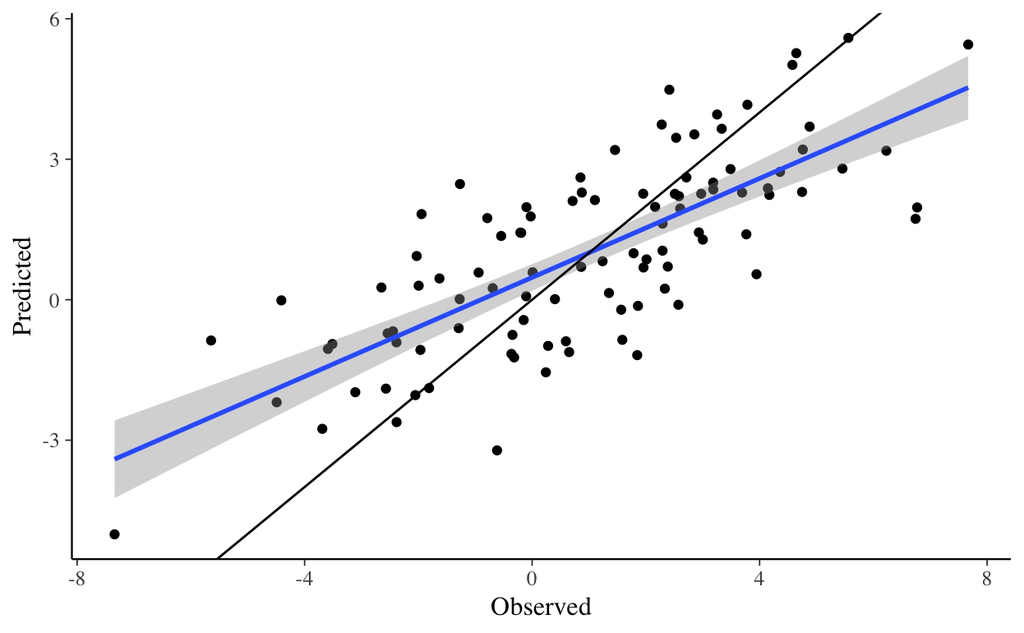

```r
library(rstanarm)
library(projpred)
library(bayesplot)

options(mc.cores = parallel::detectCores())

projection_prediction <- function(dat) {
  n <- nrow(dat)
  D <- ncol(dat[,2:10])
  p0 <- 3
  tau0 <- p0/(D - p0) * 1/sqrt(n)
  prior_coeff <- hs(global_scale = tau0, slab_scale = 1)
  fit <- stan_glm(y ~ x1 + x2 + x3 + x4 + x5 + x6 + x7 + x8 + x9, data = dat,
                  prior = prior_coeff, refresh = 0)

  vs <- varsel(fit, method = "forward")
  cvs <- cv_varsel(fit, method = "forward", verbose = FALSE)

  proj_size <- suggest_size(cvs)
  proj <- project(vs, nv = proj_size, ns = 2000)
  mcmc_intervals(as.matrix(proj),
                 pars = c("(Intercept)", names(vs$vind[1:proj_size]), "sigma"))

  pred <- proj_linpred(vs, xnew = dat[, 2:10], ynew = dat$y,
                       nv = proj_size, integrated = TRUE)
  for.plot <- data.frame(Observed = dat$y,
                         Predicted = pred$pred)
  p <- ggplot(for.plot, aes(x = Observed, y = Predicted)) +
    geom_point() +
    geom_smooth(method = "lm") +
    geom_abline(slope = 1, intercept = 0) +
    labs(x = "Observed", y = "Predicted")
  print(p)

  return(list(proj = proj, vs = vs, cvs = cvs, proj_size = proj_size))
}

summarize_posterior <- function(x, credible = 0.95, digits = 3) {
  lo_p <- (1.0 - credible)/2.0
  hi_p <- credible + lo_p
  ci <- quantile(x, c(lo_p, hi_p))
  results <- sprintf("% 5.3f (% 5.3f, % 5.3f)\n", mean(x), ci[1], ci[2])
  cat(results, sep = "")
}

summarize_results <- function(x, credible = 0.95, digits = 3) {
  vars <- colnames(as.matrix(x))
  for (i in 1:length(vars)) {
    label <- sprintf("%11s: ", vars[i])
    cat(label, sep = "")
    summarize_posterior(as.matrix(x)[,i])
  }
}

proj_1 <- projection_prediction(dat_1)
```

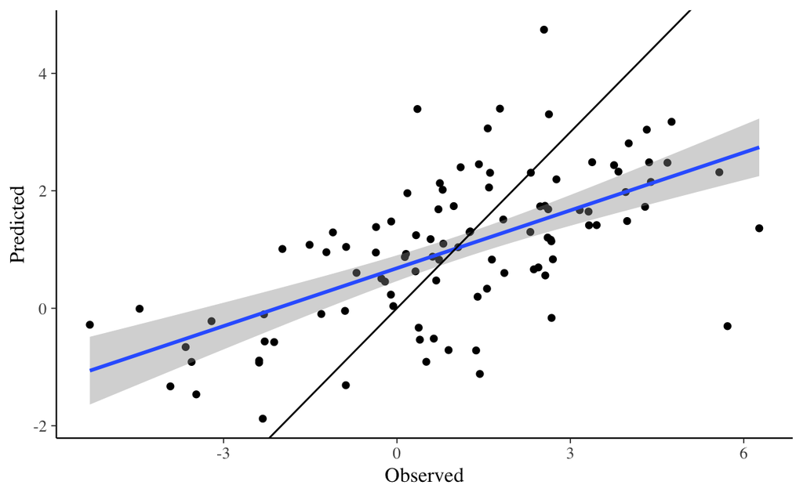

```r
proj_2 <- projection_prediction(dat_2)
```

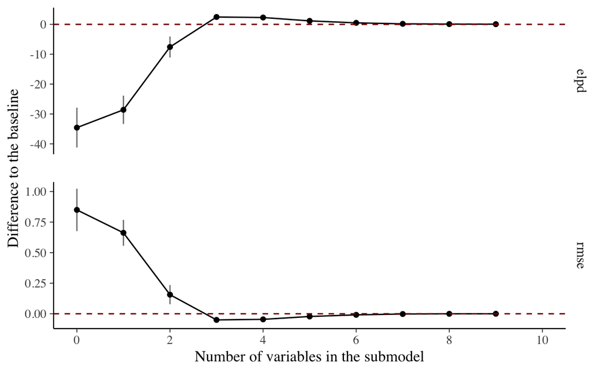

```r
print(varsel_plot(proj_1$cvs, stats = c("elpd", "rmse"), deltas = TRUE))
```

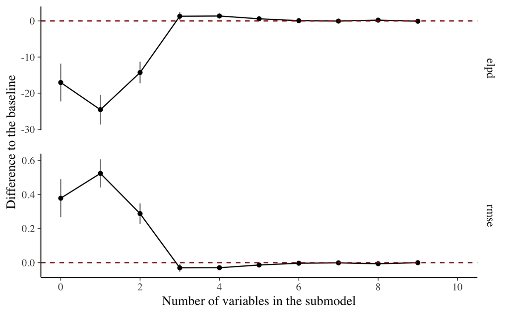

```r
print(varsel_plot(proj_2$cvs, stats = c("elpd", "rmse"), deltas = TRUE))
```

```r
summarize_results(proj_1$proj)
```

```
(Intercept):  1.087 ( 0.711,  1.466)
         x3:  1.081 ( 0.709,  1.479)
         x1:  1.159 ( 0.770,  1.529)
         x2: -0.937 (-1.363, -0.496)
      sigma:  2.018 ( 1.729,  2.342)
```

```r
summarize_results(proj_2$proj)
```

```
(Intercept):  0.920 ( 0.534,  1.304)
         x1:  0.682 ( 0.244,  1.113)
         x2: -0.794 (-1.145, -0.403)
         x3:  0.788 ( 0.282,  1.242)
      sigma:  1.986 ( 1.716,  2.321)
```

Good news! Using projection prediction to select the “important” covariates identified the same three covariates our examination of the full model suggested to us *and* those are the variables we know ore important.

## What if the “true” predictors aren’t in the data?

In our case the true predictors are `x1`, `x2`, and `x3`. We know that they influence influence `y` and that no other covariates do, because we generated the data that way. What happens if we fit a model that excludes `x1`, `x2`, and `x3` and includes only covariates that we know don’t have a “real” relationship to `y`?

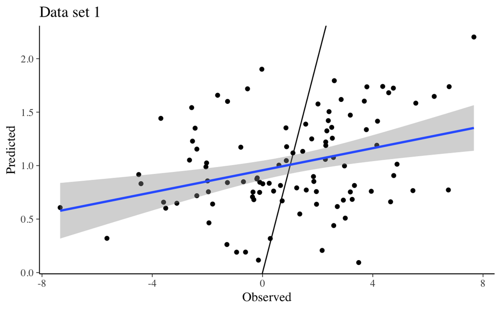

```r
n <- nrow(dat_1)
D <- ncol(dat_1[,5:10])
p0 <- 3
tau0 <- p0/(D - p0) * 1/sqrt(n)
prior_coeff <- hs(global_scale = tau0, slab_scale = 1)

fit_1 <- stan_glm(y ~ x4 + x5 + x6 + x7 + x8 + x9,
                  data = dat_1,
                  prior = prior_coeff,
                  refresh = 0,
                  adapt_delta = 0.999)
## Note: I use the same prior scale here because both data sets have the same number of observations
## and the same expected number of important covariates
##
fit_2 <- stan_glm(y ~ x4 + x5 + x6 + x7 + x8 + x9,
                  data = dat_2,
                  prior = prior_coeff,
                  refresh = 0,
                  adapt_delta = 0.999)

predict_1 <- posterior_predict(fit_1)
predict_2 <- posterior_predict(fit_2)

for.plot <- data.frame(Observed = dat_1$y, Predicted = apply(predict_1, 2, mean))
p <- ggplot(for.plot, aes(x = Observed, y = Predicted)) +
  geom_point() +
  geom_abline(slope = 1, intercept = 0) +
  geom_smooth(method = "lm") +
  ggtitle("Data set 1")
print(p)
```

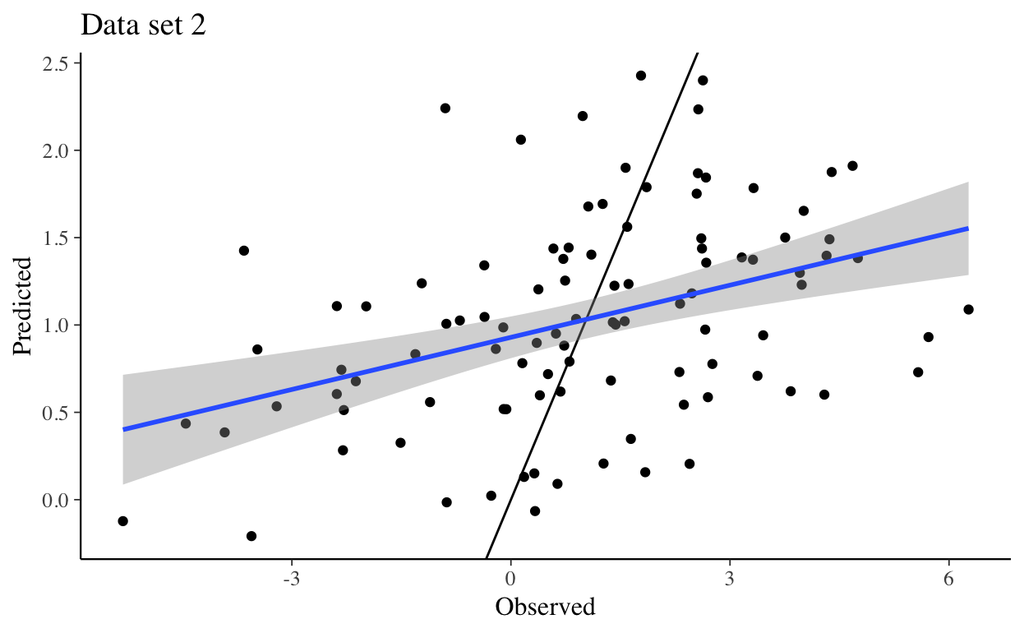

```r
for.plot <- data.frame(Observed = dat_2$y, Predicted = apply(predict_2, 2, mean))
p <- ggplot(for.plot, aes(x = Observed, y = Predicted)) +
  geom_point() +
  geom_abline(slope = 1, intercept = 0) +
  geom_smooth(method = "lm") +
  ggtitle("Data set 2")
print(p)
```

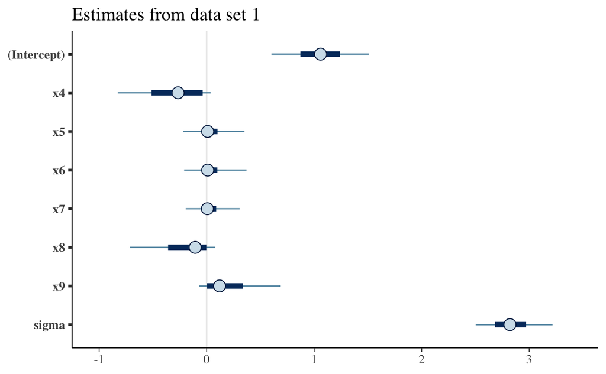

```r
p <- plot(fit_1) + ggtitle("Estimates from data set 1")
print(p)
```

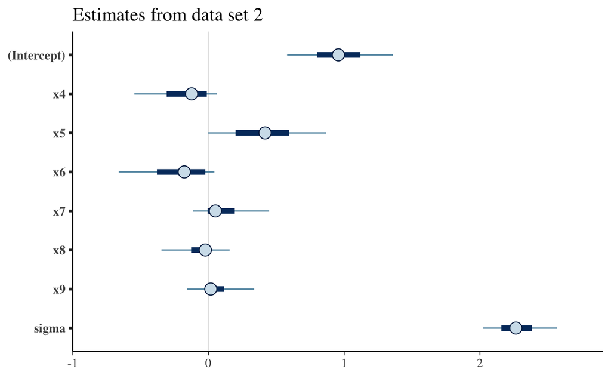

```r
p <- plot(fit_2) + ggtitle("Estimates from data set 2")
print(p)
```

```r
summary(fit_1, digits = 3)
```

```
Model Info:

 function:     stan_glm
 family:       gaussian [identity]
 formula:      y ~ x4 + x5 + x6 + x7 + x8 + x9
 algorithm:    sampling
 priors:       see help('prior_summary')
 sample:       4000 (posterior sample size)
 observations: 100
 predictors:   7

Estimates:
                mean     sd       2.5%     25%      50%      75%      97.5%
(Intercept)      1.054    0.280    0.501    0.872    1.060    1.239    1.607
x4              -0.305    0.288   -0.906   -0.513   -0.266   -0.037    0.074
x5               0.037    0.170   -0.304   -0.029    0.009    0.101    0.448
x6               0.040    0.172   -0.286   -0.031    0.010    0.100    0.476
x7               0.030    0.152   -0.280   -0.033    0.007    0.088    0.386
x8              -0.198    0.259   -0.822   -0.359   -0.107   -0.003    0.128
x9               0.194    0.244   -0.115    0.003    0.120    0.339    0.794
sigma            2.833    0.216    2.449    2.682    2.821    2.970    3.298
mean_PPD         1.020    0.393    0.219    0.764    1.022    1.283    1.786
log-posterior -287.483    4.124 -296.477 -290.003 -287.099 -284.641 -280.352

Diagnostics:
              mcse  Rhat  n_eff
(Intercept)   0.005 0.999 3389
x4            0.006 1.000 2153
x5            0.003 1.000 3722
x6            0.003 1.000 3958
x7            0.002 1.000 4489
x8            0.005 1.000 2390
x9            0.005 1.001 2438
sigma         0.003 0.999 4213
mean_PPD      0.007 1.000 3247
log-posterior 0.130 1.003 1001

For each parameter, mcse is Monte Carlo standard error, n_eff is a crude measure of effective sample size, and Rhat is the potential scale reduction factor on split chains (at convergence Rhat=1).
```

```r
summary(fit_2, digits = 3)
```

```
Model Info:

 function:     stan_glm
 family:       gaussian [identity]
 formula:      y ~ x4 + x5 + x6 + x7 + x8 + x9
 algorithm:    sampling
 priors:       see help('prior_summary')
 sample:       4000 (posterior sample size)
 observations: 100
 predictors:   7

Estimates:
                mean     sd       2.5%     25%      50%      75%      97.5%
(Intercept)      0.961    0.240    0.493    0.800    0.957    1.119    1.452
x4              -0.174    0.199   -0.628   -0.308   -0.124   -0.013    0.096
x5               0.409    0.271   -0.026    0.200    0.417    0.596    0.944
x6              -0.225    0.232   -0.746   -0.380   -0.178   -0.024    0.081
x7               0.102    0.175   -0.171   -0.006    0.051    0.193    0.522
x8              -0.057    0.152   -0.439   -0.128   -0.023    0.019    0.216
x9               0.049    0.146   -0.220   -0.023    0.017    0.115    0.393
sigma            2.278    0.167    1.982    2.158    2.265    2.385    2.634
mean_PPD         1.024    0.327    0.395    0.803    1.024    1.242    1.676
log-posterior -265.191    4.167 -274.183 -267.880 -264.860 -262.205 -258.010

Diagnostics:
              mcse  Rhat  n_eff
(Intercept)   0.003 1.000 5107
x4            0.004 1.000 3129
x5            0.006 1.002 2074
x6            0.005 1.001 2398
x7            0.003 1.001 3115
x8            0.002 0.999 4387
x9            0.002 0.999 4632
sigma         0.003 1.000 4136
mean_PPD      0.005 1.000 4396
log-posterior 0.127 1.002 1074

For each parameter, mcse is Monte Carlo standard error, n_eff is a crude measure of effective sample size, and Rhat is the potential scale reduction factor on split chains (at convergence Rhat=1).
```

```r
new_data <- data.frame(x4 = 4.0, x5 = 4.0, x6 = 4.0,
                       x7 = 4.0, x8 = 4.0, x9 = 4.0)

predict_1 <- posterior_predict(fit_1, new_data)
predict_2 <- posterior_predict(fit_2, new_data)

summarize_posterior <- function(x, credible = 0.95, digits = 3) {
  lo_p <- (1.0 - credible)/2.0
  hi_p <- credible + lo_p
  ci <- quantile(x, c(lo_p, hi_p))
  cat(round(mean(x), 3), " (", round(ci[1], 3), ",", round(ci[2], 3), ")\n", sep = "")
}

summarize_posterior(predict_1)
```

```
0.214 (-6.214,6.717)
```

```r
summarize_posterior(predict_2)
```

```
1.371 (-4.324,7.054)
```

The results from analysis of data set 1 suggest (weakly) that `x4` and `x8` have a negative association with `y`, and that `x9` has a positive associations. That’s right in the sense that (a) `x4` and `x8` are positively associated with `x2`, which we know has a negative influence on `y` and (b) `x9` is positively associated with both `x1` and `x3`, which we know have positive influences on `y`. In data set 2, `x4` and `x6` have a weakly supported negative association with `y`, while `x5` has more strongly supported positive association with `y`. Again, those associations are in the direction we’d expect. But the associations are weak. Our evidence for them is shaky.

What happens if we try the projection predictions method for variable selection?

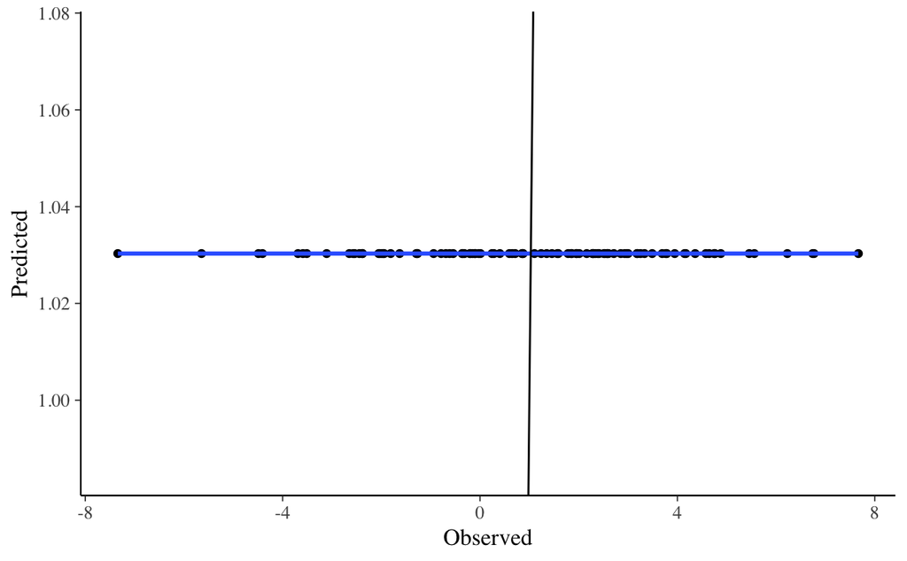

```r
projection_prediction <- function(dat) {
  n <- nrow(dat)
  D <- ncol(dat) - 1
  p0 <- 3
  tau0 <- p0/(D - p0) * 1/sqrt(n)
  prior_coeff <- hs(global_scale = tau0, slab_scale = 1)
  fit <- stan_glm(y ~ x4 + x5 + x6 + x7 + x8 + x9, data = dat,
                  prior = prior_coeff, refresh = 0)

  vs <- varsel(fit, method = "forward")
  cvs <- cv_varsel(fit, method = "forward", verbose = FALSE)

  proj_size <- suggest_size(cvs)
  proj <- project(vs, nv = proj_size, ns = 2000)
  mcmc_intervals(as.matrix(proj))

  pred <- proj_linpred(vs, xnew = dat[, -1], ynew = dat$y,
                       nv = proj_size, integrated = TRUE)
  for.plot <- data.frame(Observed = dat$y,
                         Predicted = pred$pred)
  p <- ggplot(for.plot, aes(x = Observed, y = Predicted)) +
    geom_point() +
    geom_smooth(method = "lm") +
    geom_abline(slope = 1, intercept = 0) +
    labs(x = "Observed", y = "Predicted")
  print(p)

  return(list(proj = proj, vs = vs, cvs = cvs, proj_size = proj_size))
}

proj_1 <- projection_prediction(dat_1[, -c(2,3,4,11)])
```

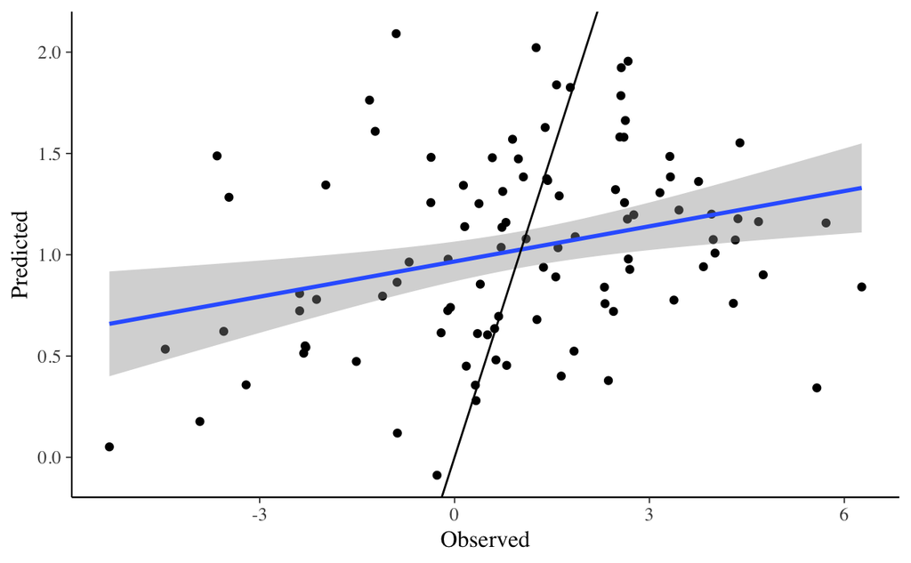

```r
proj_2 <- projection_prediction(dat_2[, -c(2,3,4,11)])
```

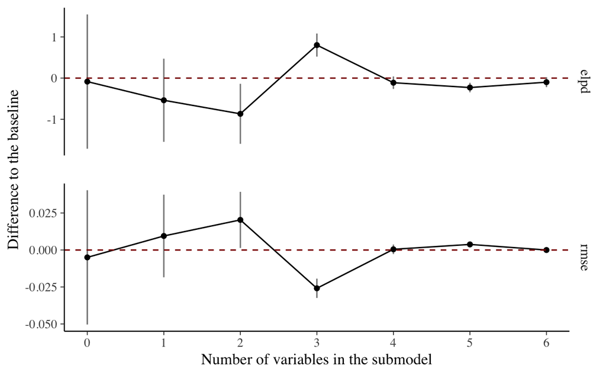

```r
print(varsel_plot(proj_1$cvs, stats = c("elpd", "rmse"), deltas = TRUE))
```

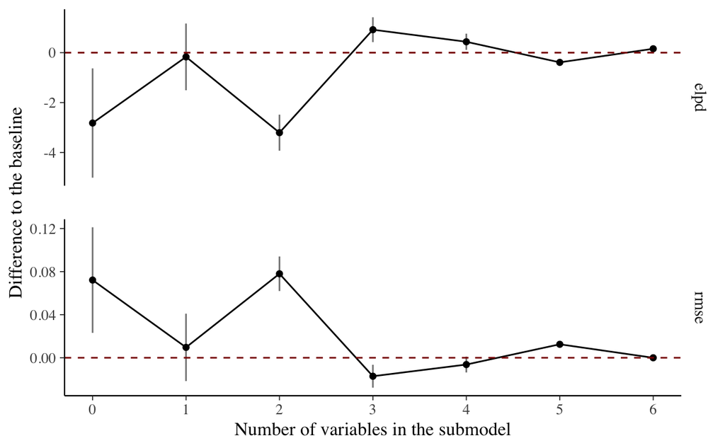

```r
print(varsel_plot(proj_2$cvs, stats = c("elpd", "rmse"), deltas = TRUE))
```

```r
summarize_results(proj_1$proj)
```

```
(Intercept): 1.011 (0.456,1.542)
      sigma: 2.902 (2.539,3.341)
```

```r
summarize_results(proj_2$proj)
```

```
(Intercept): 1.007 (0.564,1.452)
         x5: 0.482 (0.016,0.963)
      sigma: 2.327 (2.032,2.695)
```

I said that the data set 1 suggested some relationships weakly, and the projection predictions show that the relationships are so weak that we don’t have good evidence for including any of them. There’s reasonable evidence for including one covariate, `x5`, in the second data set, which means we don’t have any indication of any negative associations with `y`.[^2]

## Conclusions

{^2]: I havern’t tried running the models that exclude `x1`, `x2`, and `x3` with the strong associations (0.8 in the call to `rmvnorm()`), but I encourage you to try it on your own. I suspect you’ll find some reasonably well supported associations if you do.

[^1]: You should find it pretty easy to try the Lasso using the least squares regression in `lm()` if you’re so inclined.